# Vending Machine Analysis

Rafael Queiroz

2022-09-13

To start our analysis I would like to consider two questions, “What is the best locations to put a next vending machine?” and “Which products performend better in these machines?”. After loading the data lets have a fist look on its format.

```
##       variable q_zeros p_zeros q_na p_na q_inf p_inf      type unique
## 1       Status       0       0    0 0.00     0     0 character      2
## 2    Device.ID       0       0    0 0.00     0     0 character      5
## 3     Location       0       0    0 0.00     0     0 character      4
## 4      Machine       0       0    0 0.00     0     0 character      5
## 5      Product       0       0    0 0.00     0     0 character    171
## 6     Category       0       0    0 0.00     0     0 character      5
## 7  Transaction       0       0    0 0.00     0     0   numeric   6110
## 8    TransDate       0       0    0 0.00     0     0 character    242
## 9         Type       0       0    0 0.00     0     0 character      2
## 10       RCoil       0       0    0 0.00     0     0   integer     45
## 11      RPrice       0       0    0 0.00     0     0   numeric     14
## 12        RQty       0       0    0 0.00     0     0   integer      3
## 13       MCoil       0       0    0 0.00     0     0   integer     45
## 14      MPrice       0       0    1 0.02     0     0   numeric     14
## 15        MQty       0       0    0 0.00     0     0   integer      3
## 16   LineTotal       0       0    0 0.00     0     0   numeric     18
## 17  TransTotal       0       0    0 0.00     0     0   numeric     25
## 18   Prcd.Date       0       0    0 0.00     0     0 character    241
```

At a first look on the dataset and based on kaggle`s definition of each category we can drop some columns to have a better understanding of the problem.

First we have the object totalSales, it is an overall sum of all the sales from each vending machine.

```
##                   Machine LineTotal
## 1  BSQ Mall x1364 - Zales   1362.25
## 2    BSQ Mall x1366 - ATT   1175.25
## 3     Earle Asphalt x1371   1193.50
## 4 EB Public Library x1380   3950.25
## 5       GuttenPlans x1367   4884.25
```

We can see that the unity in Gutten Plans and the one in EB Public Library performed much better than the other three. An explanation for that would be that the machines intalled in places with other options of food performed worse because costumers had more options. We can see by the following graphic that the vending machines have a pretty linear behavior on regard of ther compound sellings.

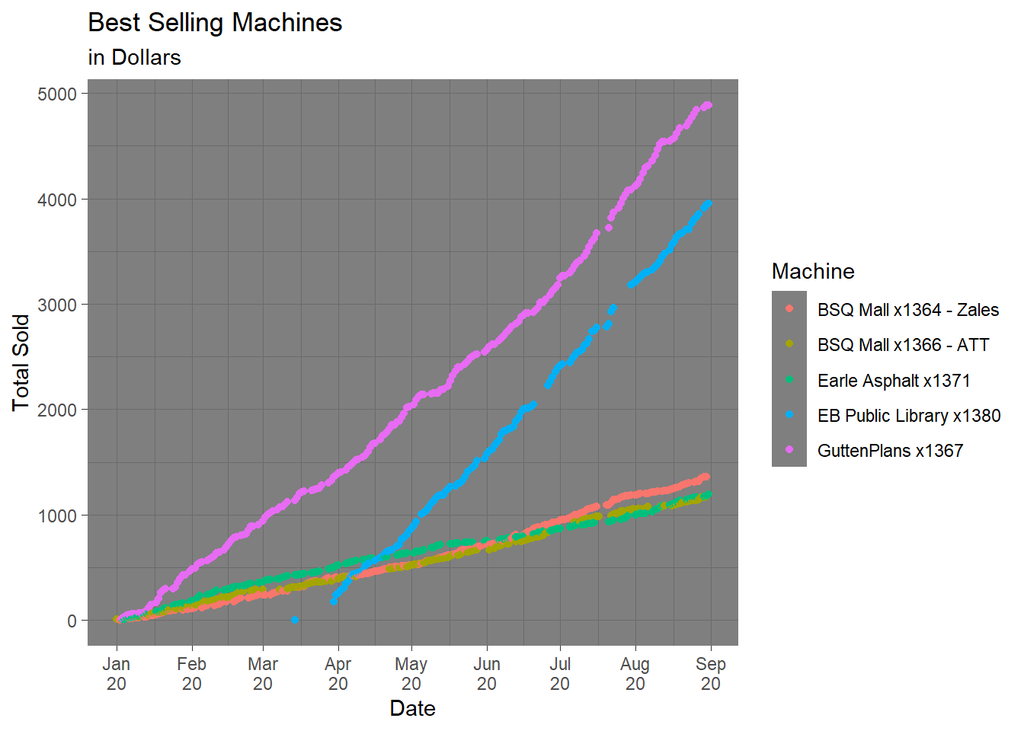

Now lets move our attention to the other part of the problem, which products were sold the most.

```
## # A tibble: 5 × 3
## # Groups:   Machine [1]
##   Machine           Product                 CumulativeSales
##   <fct>             <chr>                             <dbl>
## 1 GuttenPlans x1367 Monster Energy Original            925
## 2 GuttenPlans x1367 Red Bull - Original                480.
## 3 GuttenPlans x1367 KitKat - Crisp Wafers              415
## 4 GuttenPlans x1367 Coca Cola - Zero Sugar             344
## 5 GuttenPlans x1367 Sunkist Soda - Orange              272
```

```
## # A tibble: 5 × 3
## # Groups:   Machine [1]
##   Machine                 Product                                  CumulativeS…¹
##   <fct>                   <chr>                                            <dbl>
## 1 EB Public Library x1380 Coca Cola - Zero Sugar                            268
## 2 EB Public Library x1380 Starbucks Doubleshot Energy - Mocha               256.
## 3 EB Public Library x1380 Poland Springs Water                              190.
## 4 EB Public Library x1380 Oreo Mini - Go Paks                               137
## 5 EB Public Library x1380 Starbucks Refresher - Real Coconut Water          135
## # … with abbreviated variable name ¹CumulativeSales
```

```
## # A tibble: 5 × 3
## # Groups:   Machine [1]
##   Machine                Product                      CumulativeSales
##   <fct>                  <chr>                                  <dbl>
## 1 BSQ Mall x1364 - Zales Poland Springs Water                    226.
## 2 BSQ Mall x1364 - Zales Monster Energy Original                 126
## 3 BSQ Mall x1364 - Zales Snapple Diet Tea - Peach Tea            100
## 4 BSQ Mall x1364 - Zales Coca Cola - Zero Sugar                   96
## 5 BSQ Mall x1364 - Zales KitKat - Crisp Wafers                    62
```

```
## # A tibble: 5 × 3
## # Groups:   Machine [1]
##   Machine             Product                                       Cumulative…¹
##   <fct>               <chr>                                                <dbl>
## 1 Earle Asphalt x1371 Robert Irvine's - Fit Crunch -  Chocolate Pea        158
## 2 Earle Asphalt x1371 Wonderful Pistachios - Variety                       152
## 3 Earle Asphalt x1371 SunChips Multigrain - Harvest Cheddar                 52.5
## 4 Earle Asphalt x1371 Miss Vickie's Potato Chip - Smokehouse BBQ            51
## 5 Earle Asphalt x1371 CheezIt - Original                                    50
## # … with abbreviated variable name ¹CumulativeSales
```

```
## # A tibble: 5 × 3
## # Groups:   Machine [1]
##   Machine              Product                               CumulativeSales
##   <fct>                <chr>                                           <dbl>
## 1 BSQ Mall x1366 - ATT Monster Energy Original                         108
## 2 BSQ Mall x1366 - ATT S. Pellegrino Sparkling Mineral Water            88
## 3 BSQ Mall x1366 - ATT Poland Springs Water                             60
## 4 BSQ Mall x1366 - ATT Red Bull - Original                              49
## 5 BSQ Mall x1366 - ATT Snapple Diet Tea - Raspberry                     47.5
```

In those charts we can see the top 5 selling products of each machine. Now lets take a look on the overall top selling products, it has been filtered of only products that sold over 200 dollars.

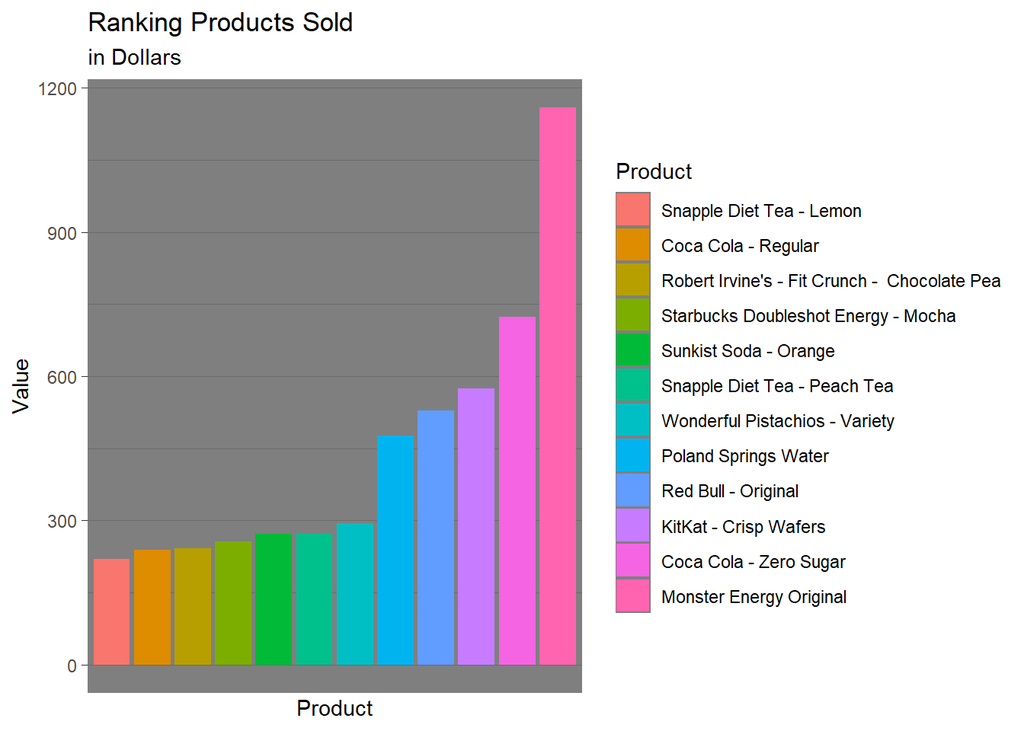

Now we can see the top sellers over all are Monster Energy Original, Coca-Cola Zero and Kitkat, specially because of the high volume sold at Gutten Plans and at the library.

To conclude any new machine installed should be placed in a location where there aren`t many options around and probably should have in its products the most sold ones.